# UK used car data analysis

###### By Pradeep Gurunathan

- Introduction
  - Packages used
- Gathering data
- Assessing data
- Cleaning data
- Store Data
- Analyze Data
- Univariate Exploration
- Bivariate Exploration
- Multivariate Exploration

## Introduction

Main focus of this report is based on the United Kingdom's Used car data collected from 1970 to 2020 nearly 100,000 car details. Data set consists of price, transmission, mileage, fuel type, road tax, miles per gallon (mpg), and engine size information. These used car consists of various brand such as Audi, VW, Skoda, BMW, etc.

Report focuses on the trends seen over the years for the used car market in UK and also get to know type of cars that are sold by the customer the most.

### Packages used

```python
# import all packages and set plots to be embedded inline
import numpy as np
import pandas as pd
import matplotlib.pyplot as plt
import seaborn as sns
import datetime
import glob
import os

%matplotlib inline

import warnings
warnings.filterwarnings('ignore')
```

## Preliminary Wrangling

This document explores the United kingdom's Used car data containing cars from 1970 to 2020.

## Gathering data

Source for this analysis the data can be found in kaggle [here](https://www.kaggle.com/adityadesai13/used-car-dataset-ford-and-mercedes).

Individual dataset is downloaded and mergered to for a single dataset for data cleaning.

```python
audi=pd.read_csv('audi.csv')
audi['brand']="Audi"
bmw=pd.read_csv('bmw.csv')
bmw['brand']="BMW"
ford=pd.read_csv('ford.csv')
ford['brand']="Ford"
hyundi=pd.read_csv('hyundi.csv')
hyundi['brand']="Hyundi"
merc=pd.read_csv('merc.csv')
merc['brand']="Mercedes"
skoda=pd.read_csv('skoda.csv')
skoda['brand']="Skoda"
toyota=pd.read_csv('toyota.csv')
toyota['brand']="Toyota"
vauxhall=pd.read_csv('vauxhall.csv')
vauxhall['brand']="Vauxhall"
vw=pd.read_csv('vw.csv')
vw['brand']="Volkswagen"

used_cars=pd.concat([audi, bmw,ford,hyundi,merc,skoda,toyota,vauxhall,vw], ignore_index=True)
used_cars.to_csv('used_cars.csv', index = False)
```

## Assessing Data

In this section data is assess that was gathered, both visually and programmatically for quality and tidiness issues.

The quality of data is assessed against dimensions or criteria concerning the content: completeness, validity, accuracy and consistency.

```python
used_cars = pd.read_csv('used_cars.csv')
```

```python
used_cars.head(10)
```

|  | model | year | price | transmission | mileage | fuelType | tax | mpg | engineSize | brand |
| --- | --- | --- | --- | --- | --- | --- | --- | --- | --- | --- |
| 0 | A1 | 2017 | 12500 | Manual | 15735 | Petrol | 150 | 55.4 | 1.4 | Audi |
| 1 | A6 | 2016 | 16500 | Automatic | 36203 | Diesel | 20 | 64.2 | 2.0 | Audi |
| 2 | A1 | 2016 | 11000 | Manual | 29946 | Petrol | 30 | 55.4 | 1.4 | Audi |
| 3 | A4 | 2017 | 16800 | Automatic | 25952 | Diesel | 145 | 67.3 | 2.0 | Audi |
| 4 | A3 | 2019 | 17300 | Manual | 1998 | Petrol | 145 | 49.6 | 1.0 | Audi |
| 5 | A1 | 2016 | 13900 | Automatic | 32260 | Petrol | 30 | 58.9 | 1.4 | Audi |
| 6 | A6 | 2016 | 13250 | Automatic | 76788 | Diesel | 30 | 61.4 | 2.0 | Audi |
| 7 | A4 | 2016 | 11750 | Manual | 75185 | Diesel | 20 | 70.6 | 2.0 | Audi |
| 8 | A3 | 2015 | 10200 | Manual | 46112 | Petrol | 20 | 60.1 | 1.4 | Audi |
| 9 | A1 | 2016 | 12000 | Manual | 22451 | Petrol | 30 | 55.4 | 1.4 | Audi |

```python
used_cars.tail(10)
```

|  | model | year | price | transmission | mileage | fuelType | tax | mpg | engineSize | brand |
| --- | --- | --- | --- | --- | --- | --- | --- | --- | --- | --- |
| 99177 | Eos | 2008 | 4995 | Manual | 65000 | Diesel | 195 | 48.0 | 2.0 | Volkswagen |
| 99178 | Eos | 2008 | 3695 | Automatic | 127000 | Petrol | 280 | 34.5 | 2.0 | Volkswagen |
| 99179 | Eos | 2015 | 12495 | Manual | 41850 | Diesel | 125 | 58.9 | 2.0 | Volkswagen |
| 99180 | Eos | 2014 | 8950 | Manual | 58000 | Diesel | 125 | 58.9 | 2.0 | Volkswagen |
| 99181 | Eos | 2006 | 2995 | Manual | 92640 | Diesel | 200 | 48.0 | 2.0 | Volkswagen |
| 99182 | Eos | 2012 | 5990 | Manual | 74000 | Diesel | 125 | 58.9 | 2.0 | Volkswagen |
| 99183 | Fox | 2008 | 1799 | Manual | 88102 | Petrol | 145 | 46.3 | 1.2 | Volkswagen |
| 99184 | Fox | 2009 | 1590 | Manual | 70000 | Petrol | 200 | 42.0 | 1.4 | Volkswagen |
| 99185 | Fox | 2006 | 1250 | Manual | 82704 | Petrol | 150 | 46.3 | 1.2 | Volkswagen |
| 99186 | Fox | 2007 | 2295 | Manual | 74000 | Petrol | 145 | 46.3 | 1.2 | Volkswagen |

```python
# Information of the dataset
used_cars.info(verbose=True,null_counts=True)
```

```
<class 'pandas.core.frame.DataFrame'>
RangeIndex: 99187 entries, 0 to 99186
Data columns (total 10 columns):
 #   Column        Non-Null Count  Dtype
---  ------        --------------  -----
 0   model         99187 non-null  object
 1   year          99187 non-null  int64
 2   price         99187 non-null  int64
 3   transmission  99187 non-null  object
 4   mileage       99187 non-null  int64
 5   fuelType      99187 non-null  object
 6   tax           99187 non-null  int64
 7   mpg           99187 non-null  float64
 8   engineSize    99187 non-null  float64
 9   brand         99187 non-null  object
dtypes: float64(2), int64(4), object(4)
memory usage: 7.6+ MB
```

> **fuelType, transmission and brand should be category format.**

```python
# Description for stats figures
used_cars.describe()
```

|  | year | price | mileage | tax | mpg | engineSize |
| --- | --- | --- | --- | --- | --- | --- |
| count | 99187.000000 | 99187.000000 | 99187.000000 | 99187.000000 | 99187.000000 | 99187.000000 |
| mean | 2017.087723 | 16805.347656 | 23058.914213 | 120.299838 | 55.166825 | 1.663280 |
| std | 2.123934 | 9866.773417 | 21148.523721 | 63.150926 | 16.138522 | 0.557646 |
| min | 1970.000000 | 450.000000 | 1.000000 | 0.000000 | 0.300000 | 0.000000 |
| 25% | 2016.000000 | 9999.000000 | 7425.000000 | 125.000000 | 47.100000 | 1.200000 |
| 50% | 2017.000000 | 14495.000000 | 17460.000000 | 145.000000 | 54.300000 | 1.600000 |
| 75% | 2019.000000 | 20870.000000 | 32339.000000 | 145.000000 | 62.800000 | 2.000000 |
| max | 2060.000000 | 159999.000000 | 323000.000000 | 580.000000 | 470.800000 | 6.600000 |

```python
used_cars[used_cars.price==used_cars.price.max()]
```

|  | model | year | price | transmission | mileage | fuelType | tax | mpg | engineSize | brand |
| --- | --- | --- | --- | --- | --- | --- | --- | --- | --- | --- |
| 50473 | G Class | 2020 | 159999 | Semi-Auto | 1350 | Petrol | 145 | 21.4 | 4.0 | Mercedes |

> **Above data is valid because average price of G-Class is around 150000 pounds.**

```python
used_cars[used_cars.year>2020]
```

|  | model | year | price | transmission | mileage | fuelType | tax | mpg | engineSize | brand |
| --- | --- | --- | --- | --- | --- | --- | --- | --- | --- | --- |
| 39175 | Fiesta | 2060 | 6495 | Automatic | 54807 | Petrol | 205 | 42.8 | 1.4 | Ford |

> **Above data is invalid since it is more than current year(2020)**

```python
used_cars.query('engineSize==0 and fuelType!="Electric"')
```

|  | model | year | price | transmission | mileage | fuelType | tax | mpg | engineSize | brand |
| --- | --- | --- | --- | --- | --- | --- | --- | --- | --- | --- |
| 7505 | Q5 | 2019 | 44790 | Automatic | 5886 | Petrol | 135 | 117.7 | 0.0 | Audi |
| 7506 | Q3 | 2019 | 32788 | Automatic | 1500 | Diesel | 145 | 47.1 | 0.0 | Audi |
| 7516 | Q3 | 2020 | 29944 | Manual | 1500 | Petrol | 145 | 40.9 | 0.0 | Audi |
| 7517 | Q3 | 2020 | 33333 | Automatic | 1500 | Diesel | 145 | 47.1 | 0.0 | Audi |
| 7518 | Q3 | 2020 | 29944 | Automatic | 1500 | Petrol | 145 | 32.5 | 0.0 | Audi |
| ... | ... | ... | ... | ... | ... | ... | ... | ... | ... | ... |
| 95678 | Tiguan | 2016 | 15300 | Manual | 38398 | Diesel | 145 | 53.3 | 0.0 | Volkswagen |
| 95685 | Tiguan | 2018 | 24000 | Automatic | 22200 | Diesel | 145 | 47.9 | 0.0 | Volkswagen |
| 96851 | Up | 2017 | 8500 | Manual | 20324 | Petrol | 20 | 64.2 | 0.0 | Volkswagen |
| 96909 | Up | 2017 | 8000 | Manual | 24444 | Petrol | 20 | 60.1 | 0.0 | Volkswagen |
| 97342 | Beetle | 2017 | 13800 | Manual | 17859 | Petrol | 125 | 53.3 | 0.0 | Volkswagen |

271 rows × 10 columns

> **These 271 entries have engineSize equal to 0 which is invalid since these car are not electic cars.**

```python
used_cars.mpg.describe(percentiles=[.99])
```

```
count    99187.000000
mean        55.166825
std         16.138522
min          0.300000
50%         54.300000
99%         85.600000
max        470.800000
Name: mpg, dtype: float64
```

> It's clear that around 99% of the cars have mpg less 85.6.

> **Records with more than 86 mpg is removed for this analyis**

```python
used_cars.mileage.describe(percentiles=[.99])
```

```
count     99187.000000
mean      23058.914213
std       21148.523721
min           1.000000
50%       17460.000000
99%       96215.380000
max      323000.000000
Name: mileage, dtype: float64
```

> It's clear that around 99% of the cars have mileage less than 96215.

> **Records with more than 96216 mileage is removed for this analyis**

### Quality Issues

**Before we go ahead with visualization, there are some quality and tidiness issues that need to be cleaned.**

- The following columns are not in category format:
  - fuelType
  - transmission
  - brand
- Data with manufacturing year more than current year(2020) need to be removed.
- Remove 271 entries have engineSize equal to 0 which is invalid since these car are not electic cars.
- Records with more than 86 mpg is removed for this analyis
- Records with more than 96216 mileage is removed for this analyis
- For Data enhancment Age of the cars are calculated from the current year.

### Tidiness Issues

- Dataset should be cleaned to form a Master Dataset future visualization purpose

## Cleaning data

Cleaning the Gathered Data based assessment of data.

Before cleaning we are taking a copy of the data.

```python
# create copies of the dataframes for cleaning
used_cars_clean= used_cars.copy()
```

### Define

**Converting columns to the appropriate data type:**

- fuelType, transmission and brand columns to category format.

### Code

```python
# Converting columns to category format
used_cars_clean.fuelType=used_cars_clean.fuelType.astype('category')
used_cars_clean.transmission=used_cars_clean.transmission.astype('category')
used_cars_clean.brand=used_cars_clean.brand.astype('category')
```

### Test

```python
used_cars_clean.info(verbose=True, null_counts=True)
```

```
<class 'pandas.core.frame.DataFrame'>
RangeIndex: 99187 entries, 0 to 99186
Data columns (total 10 columns):
 #   Column        Non-Null Count  Dtype
---  ------        --------------  -----
 0   model         99187 non-null  object
 1   year          99187 non-null  int64
 2   price         99187 non-null  int64
 3   transmission  99187 non-null  category
 4   mileage       99187 non-null  int64
 5   fuelType      99187 non-null  category
 6   tax           99187 non-null  int64
 7   mpg           99187 non-null  float64
 8   engineSize    99187 non-null  float64
 9   brand         99187 non-null  category
dtypes: category(3), float64(2), int64(4), object(1)
memory usage: 5.6+ MB
```

### Define

> Data with manufacturing year more than current year(2020) need to be removed

### Code

```python
used_cars_clean=used_cars_clean.query('year<=2020')
```

### Test

```python
used_cars_clean.info(verbose=True,null_counts=True)
```

```
<class 'pandas.core.frame.DataFrame'>
Int64Index: 99186 entries, 0 to 99186
Data columns (total 10 columns):
 #   Column        Non-Null Count  Dtype
---  ------        --------------  -----
 0   model         99186 non-null  object
 1   year          99186 non-null  int64
 2   price         99186 non-null  int64
 3   transmission  99186 non-null  category
 4   mileage       99186 non-null  int64
 5   fuelType      99186 non-null  category
 6   tax           99186 non-null  int64
 7   mpg           99186 non-null  float64
 8   engineSize    99186 non-null  float64
 9   brand         99186 non-null  category
dtypes: category(3), float64(2), int64(4), object(1)
memory usage: 6.3+ MB
```

### Define

> Remove 271 entries have engineSize equal to 0 which is invalid since these car are not electic cars.

### Code

```python
used_cars_clean=used_cars_clean.query('(engineSize!=0) and (engineSize!=0 or fuelType=="Electric")')
```

### Test

```python
used_cars_clean.info(verbose=True,null_counts=True)
```

```
<class 'pandas.core.frame.DataFrame'>
Int64Index: 98913 entries, 0 to 99186
Data columns (total 10 columns):
 #   Column        Non-Null Count  Dtype
---  ------        --------------  -----
 0   model         98913 non-null  object
 1   year          98913 non-null  int64
 2   price         98913 non-null  int64
 3   transmission  98913 non-null  category
 4   mileage       98913 non-null  int64
 5   fuelType      98913 non-null  category
 6   tax           98913 non-null  int64
 7   mpg           98913 non-null  float64
 8   engineSize    98913 non-null  float64
 9   brand         98913 non-null  category
dtypes: category(3), float64(2), int64(4), object(1)
memory usage: 6.3+ MB
```

```python
used_cars_clean.query('engineSize==0 and fuelType!="Electric"')
```

|  | model | year | price | transmission | mileage | fuelType | tax | mpg | engineSize | brand |
| --- | --- | --- | --- | --- | --- | --- | --- | --- | --- | --- |

### Define

> Records with more than 86 mpg is removed for this analyis

### Code

```python
used_cars_clean=used_cars_clean.query('mpg<=86')
```

### Test

```python
used_cars_clean.mpg.describe(percentiles=[.99])
```

```
count    98201.000000
mean        54.388820
std         11.239331
min          0.300000
50%         54.300000
99%         78.500000
max         86.000000
Name: mpg, dtype: float64
```

### Define

> Records with more than 96216 mileage is removed for this analyis

### Code

```python
used_cars_clean=used_cars_clean.query('mileage<=96216')
```

### Test

```python
used_cars_clean.mileage.describe(percentiles=[.99])
```

```
count    97219.000000
mean     22072.370946
std      18913.706260
min          1.000000
50%      17142.000000
99%      83000.000000
max      96213.000000
Name: mileage, dtype: float64
```

### Define

> Reset the index of the dataframe.

### Code

```python
used_cars_clean.reset_index(drop=True,inplace=True)
```

```python
used_cars_clean.index
```

```
RangeIndex(start=0, stop=97219, step=1)
```

### Define

> For Data enhancment Age of the cars are calculated from the current year.

### Code

```python
now = datetime.datetime.now()
used_cars_clean['CarAge']=(now.year+1)-used_cars_clean.year
```

### Test

```python
used_cars_clean.head()
```

|  | model | year | price | transmission | mileage | fuelType | tax | mpg | engineSize | brand | CarAge |
| --- | --- | --- | --- | --- | --- | --- | --- | --- | --- | --- | --- |
| 0 | A1 | 2017 | 12500 | Manual | 15735 | Petrol | 150 | 55.4 | 1.4 | Audi | 4 |
| 1 | A6 | 2016 | 16500 | Automatic | 36203 | Diesel | 20 | 64.2 | 2.0 | Audi | 5 |
| 2 | A1 | 2016 | 11000 | Manual | 29946 | Petrol | 30 | 55.4 | 1.4 | Audi | 5 |
| 3 | A4 | 2017 | 16800 | Automatic | 25952 | Diesel | 145 | 67.3 | 2.0 | Audi | 4 |
| 4 | A3 | 2019 | 17300 | Manual | 1998 | Petrol | 145 | 49.6 | 1.0 | Audi | 2 |

```python
used_cars_clean.info()
```

```
<class 'pandas.core.frame.DataFrame'>
RangeIndex: 97219 entries, 0 to 97218
Data columns (total 11 columns):
 #   Column        Non-Null Count  Dtype
---  ------        --------------  -----
 0   model         97219 non-null  object
 1   year          97219 non-null  int64
 2   price         97219 non-null  int64
 3   transmission  97219 non-null  category
 4   mileage       97219 non-null  int64
 5   fuelType      97219 non-null  category
 6   tax           97219 non-null  int64
 7   mpg           97219 non-null  float64
 8   engineSize    97219 non-null  float64
 9   brand         97219 non-null  category
 10  CarAge        97219 non-null  int64
dtypes: category(3), float64(2), int64(5), object(1)
memory usage: 6.2+ MB
```

### **Saving the cleaned master dataset to a new file**

```python
used_cars_clean.to_csv('used_cars_master.csv', index=False)
```

### What is the structure of dataset?

> Data that was gathered from the kaggle is straight forward to understand. After data cleaning data is much more better for our visualization.

> Around 97219 record has been retained after data cleaning from the UK's used car data collected from 1970 to 2020.

> Structure of the dataset is as follows:-
> - model - mode name
> - year - manufacturing year
> - price
> - transmission
> - mileage
> - fueltype
> - tax
> - mpg
> - enginesize
> - brand- car brand
> - CarAge

### What are the main features of interest in dataset?

> Important feature in the dataset is car manufacture year and car age. Apart from this transmission type and fuel type also interesting fields to answer our questions related to the trends seen in UK's used car market.

### What features in the dataset do you think will help support your investigation into your feature(s) of interest?

> Car Age, transmission type and fuel type features will definitly support our answer related to UK's used car market trends.

## Univariate Exploration

> In this section, investigate distributions of individual variables.

**Read the Cleaned Master dataset**

```python
used_cars_master=pd.read_csv('used_cars_master.csv')
```

### How is the UK's used car trend based on the car manufacturing year?

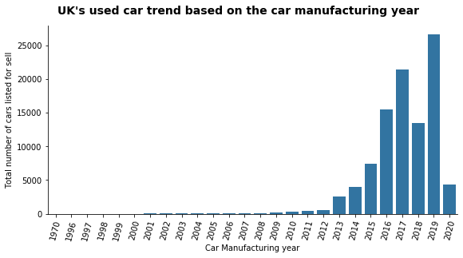

```python
base_color = sns.color_palette()[0]
g = sns.catplot(data=used_cars_master,x='year',kind='count',color=base_color,height=4, aspect=8/4)
g.set_axis_labels('Car Manufacturing year','Total number of cars listed for sell')
g.fig.suptitle("UK's used car trend based on the car manufacturing year",y=1.05,fontsize=14,fontweight='bold')
g.set_xticklabels(rotation=75);
```

> **As per the bar plot it is evident that cars with 2019 manufacturing year is listed highest in the UK's used car market. Cars with manufacturing year less than 2013 is very less compare to other years.**

### How is the UK's used car trend based on the car's Age?

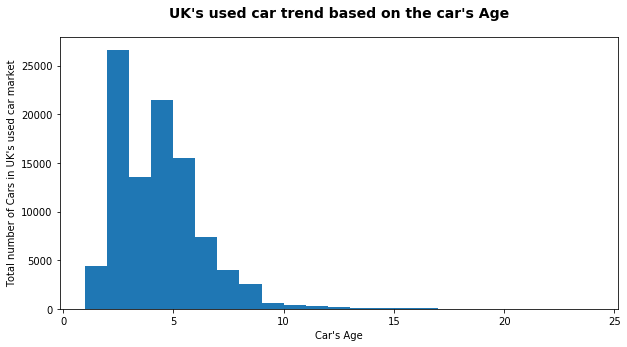

```python
bin_edges = np.arange(1,25,1)
plt.figure(figsize=(10,5))
plt.hist(data=used_cars_master,x='CarAge',bins=bin_edges)
plt.title("UK's used car trend based on the car's Age", y=1.05, fontsize=14, fontweight='bold')
plt.xlabel("Car's Age")
plt.ylabel("Total number of Cars in UK's used car market");
```

```python
used_cars_master.CarAge.mean()
```

```
3.8560055133255844
```

```python
used_cars_master.CarAge.median()
```

```
4.0
```

```python
used_cars_master.CarAge.mode()
```

```
0    2
dtype: int64
```

> **Based on the histogram mean UK car's age is 4 and majority of the cars are two year old that are listed in UK's used car markrt.**

### How is the UK's used car trend based on the car's Transmission type?

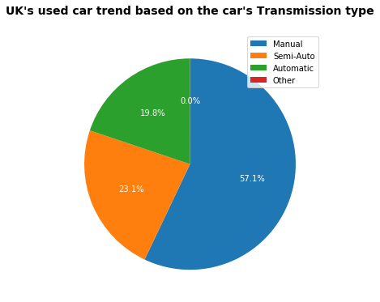

```python
transmission = used_cars_master.transmission.value_counts()
plt.figure(figsize=(10,6))
plt.pie(transmission, labels = transmission.index, startangle = 90, autopct= '%1.1f%%', counterclock = False, textprops={'color':'white'});
plt.title("UK's used car trend based on the car's Transmission type", y=1.05, fontsize=14, fontweight='bold');
plt.legend();
```

> **In UK's used car market Manual cars are listed more than other car's transmissions. it is interesting to know Semi-automatic transmission cars are more than Automatic cars.**

### How is the UK's used car trend based on the car's Fuel type?

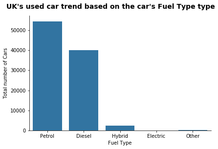

```python
fueltype = ['Petrol', 'Diesel', 'Hybrid', 'Electric','Other']
g = sns.catplot(data=used_cars_master,x='fuelType',kind='count',color=base_color,order=fueltype,height=4, aspect=6/4)
g.set_axis_labels('Fuel Type','Total number of Cars')
g.fig.suptitle("UK's used car trend based on the car's Fuel Type type",y=1.05,fontsize=14,fontweight='bold')
g.set_xticklabels(rotation=0);
```

> **More than 50,000 petrol cars are listed in UK's used car market compared to other fuel type cars.**

### Discuss the distribution(s) of your variable(s) of interest. Were there any unusual points? Did you need to perform any transformations?

> There was not much unsual points seen in the univariate exploration. Mostly petrol cars and cars with manual cars are listed more in UK's used car market. One interesting finding was there are more semi-automatic cars listed than automatic cars in the UK's used car market list.

### Of the features you investigated, were there any unusual distributions? Did you perform any operations on the data to tidy, adjust, or change the form of the data? If so, why did you do this?

> Since record with future manufacturing date was removed and from the Age of the cars that was calculated helped to understand data more clearly. From the cleaned data majority of car are two years old that are listed in UK's used car market and average of 4 year old cars are seen in the listing.

## Bivariate Exploration

> In this section, investigate relationships between pairs of variables in your data.

### How is the UK's used car trend based on the car's Fuel type and mpg?

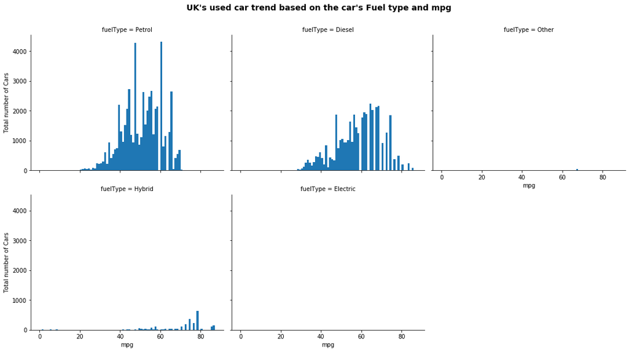

```python
bins = np.arange(0,86+2,1)
g = sns.FacetGrid(data=used_cars_master,col='fuelType',col_wrap=3,
    height=4,
    aspect=5/4)

g.map(plt.hist,'mpg',bins=bins)
g.set_axis_labels('mpg','Total number of Cars')
g.fig.suptitle("UK's used car trend based on the car's Fuel type and mpg",y=1.05,fontsize=14,fontweight='bold');
```

> **Petrol cars with less than 60 mpg are listed more compare to cars more than 60 mpg. Incontrast diesel cars with less than 60 mpg are listed less compare to cars more than 60 mpg.**

### How is the UK's used car trend based on the car's Fuel type and Transmission?

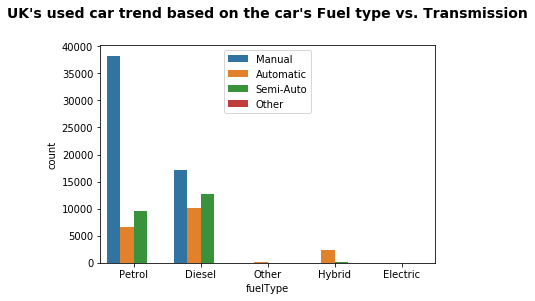

```python
sns.countplot(data=used_cars_master,x='fuelType',hue='transmission')
plt.xticks(rotation=0)
plt.legend(loc="upper center")
plt.title("UK's used car trend based on the car's Fuel type vs. Transmission",y=1.1,fontsize=14,fontweight='bold');
```

> **In both petrol and diesel cars manual transmission type predominant when compared to other transmission types. In hybrid cars automatic transmission type is more compare to other hybrid transmission types.**

### Is there any relationship between dataset features?

```python
corr = used_cars_master.corr()
corr.style.background_gradient(cmap='coolwarm').set_precision(2)
```

|  | year | price | mileage | tax | mpg | engineSize | CarAge |
| --- | --- | --- | --- | --- | --- | --- | --- |
| year | 1.00 | 0.49 | -0.74 | 0.24 | -0.22 | -0.02 | -1.00 |
| price | 0.49 | 1.00 | -0.42 | 0.32 | -0.48 | 0.66 | -0.49 |
| mileage | -0.74 | -0.42 | 1.00 | -0.26 | 0.28 | 0.10 | 0.74 |
| tax | 0.24 | 0.32 | -0.26 | 1.00 | -0.59 | 0.28 | -0.24 |
| mpg | -0.22 | -0.48 | 0.28 | -0.59 | 1.00 | -0.33 | 0.22 |
| engineSize | -0.02 | 0.66 | 0.10 | 0.28 | -0.33 | 1.00 | 0.02 |
| CarAge | -1.00 | -0.49 | 0.74 | -0.24 | 0.22 | 0.02 | 1.00 |

> **It is clear from correlation matrix there is a negative relationship between cars manufacture yesr and number of mileage of the cars. In contrast there is positive relationship between the age of cars and mileage.**

### Relationship between Car age and mileage

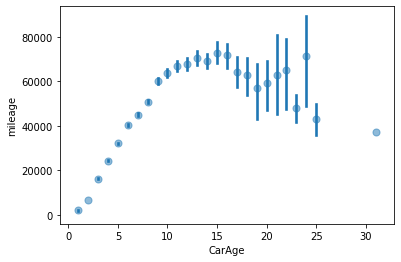

```python
bins=np.arange(0,30+2,1)
sns.regplot(data=used_cars_master, x='CarAge',y='mileage',y_jitter=.5,x_bins=bins,fit_reg=False,
           scatter_kws={'alpha': 1/2
                       });
```

> **There is strong relationship between cars age and mileage for the cars listed UK's used cars market. Cars that are 15 to 25 years old are having more mileage when compared to lesser aged cars.**

### Talk about some of the relationships you observed in this part of the investigation. How did the feature(s) of interest vary with other features in the dataset?

> Petrol cars with less than 60 mpg are listed more compare to cars more than 60 mpg. Incontrast diesel cars with less than 60 mpg are listed less compare to cars more than 60 mpg.

### Did you observe any interesting relationships between the other features (not the main feature(s) of interest)?

> There is strong relationship between cars age and mileage for the cars listed UK's used cars market. Cars that are 15 to 25 years old are having more mileage when compared to lesser aged cars.

## Multivariate Exploration

> Create plots of three or more variables to investigate your data even further.

### Relationship between UK's used cars price based fuel type and transmission

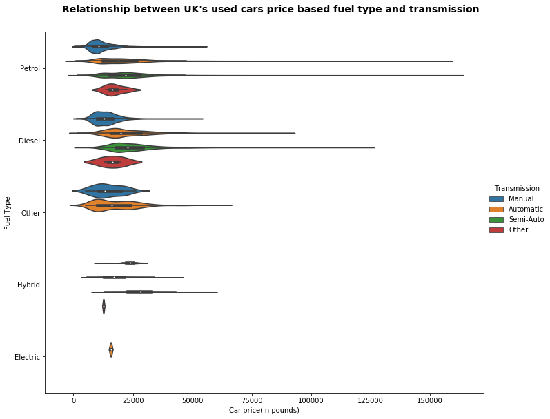

```python
g = sns.catplot(data=used_cars_master, y='fuelType', x="price", hue="transmission", kind="violin",height=8,aspect=10/8);
g.set_axis_labels("Car price(in pounds)","Fuel Type")
g._legend.set_title('Transmission')
g.fig.suptitle("Relationship between UK's used cars price based fuel type and transmission", y=1.05, fontsize=14, fontweight='bold');
```

> **For petrol cars** price of manual transmission cars are less compared to other transmission type cars. Semi-automatic cars are more costlier compared to other petrol transmission type cars.

> **For diesel cars** price of different transmission type are more less similar to petrol cars.

> **For other fuel type** cars the price of automatic transmission type are more compared to manual. There are no semi-automatic and other transmission type cars in this fuel type.

> **For Hybrid** type cars average price of manual transmission type is more compared to automatic transmission type. But price range of automatic and semi-automatic transmission type are more compare to manual type and other transmission type.

> **All electric cars are automatic**

### UK's used cars age based on the fuel type and car brands.

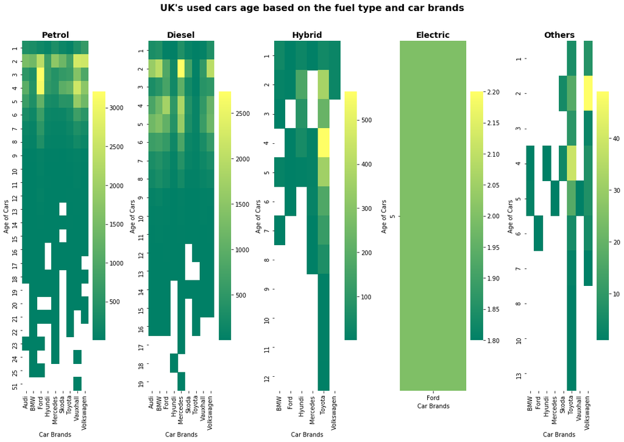

```python
plt.figure(figsize=(15,10))
plt.suptitle("UK's used cars age based on the fuel type and car brands", y=1.05, fontsize=16, fontweight='bold');

plt.subplot(1,5,1)
used_cars_copy=used_cars_master.copy()
used_cars_copy['id']=used_cars_copy.index
used_cars_df = used_cars_copy.query('fuelType == "Petrol"').groupby(["CarAge", "brand"])["id"].size().reset_index()
used_cars_df = used_cars_df.pivot('CarAge','brand','id')
sns.heatmap(used_cars_df,cmap='summer')
plt.title("Petrol", y=1.015, fontsize=14, fontweight='bold')
plt.xlabel('Car Brands')
plt.ylabel('Age of Cars');

plt.subplot(1,5,2)
used_cars_copy=used_cars_master.copy()
used_cars_copy['id']=used_cars_copy.index
used_cars_df = used_cars_copy.query('fuelType == "Diesel"').groupby(["CarAge", "brand"])["id"].size().reset_index()
used_cars_df = used_cars_df.pivot('CarAge','brand','id')
sns.heatmap(used_cars_df,cmap='summer')
plt.title("Diesel", y=1.015, fontsize=14, fontweight='bold')
plt.xlabel('Car Brands')
plt.ylabel('Age of Cars');

plt.subplot(1,5,3)
used_cars_copy=used_cars_master.copy()
used_cars_copy['id']=used_cars_copy.index
used_cars_df = used_cars_copy.query('fuelType == "Hybrid"').groupby(["CarAge", "brand"])["id"].size().reset_index()
used_cars_df = used_cars_df.pivot('CarAge','brand','id')
sns.heatmap(used_cars_df,cmap='summer')
plt.title("Hybrid", y=1.015, fontsize=14, fontweight='bold')
plt.xlabel('Car Brands')
plt.ylabel('Age of Cars');

plt.subplot(1,5,4)
used_cars_copy=used_cars_master.copy()
used_cars_copy['id']=used_cars_copy.index
used_cars_df = used_cars_copy.query('fuelType == "Electric"').groupby(["CarAge", "brand"])["id"].size().reset_index()
used_cars_df = used_cars_df.pivot('CarAge','brand','id')
sns.heatmap(used_cars_df,cmap='summer')
plt.title("Electric", y=1.015, fontsize=14, fontweight='bold')
plt.xlabel('Car Brands')
plt.ylabel('Age of Cars');

plt.subplot(1,5,5)
used_cars_copy=used_cars_master.copy()
used_cars_copy['id']=used_cars_copy.index
used_cars_df = used_cars_copy.query('fuelType == "Other"').groupby(["CarAge", "brand"])["id"].size().reset_index()
used_cars_df = used_cars_df.pivot('CarAge','brand','id')
sns.heatmap(used_cars_df,cmap='summer')
plt.title("Others", y=1.015, fontsize=14, fontweight='bold')
plt.xlabel('Car Brands')
plt.ylabel('Age of Cars');
plt.tight_layout()
```

> In **Diesel** cars category cars age range from 1 to 19 years. Majority of Mercedes cars are 2 years old. Mercedes is the old Diesel car brand listed in UK's used car market.

> In **Hybrid** cars category cars age range from 1 to 12 years. Majority of Toyota cars are ranged between 2 and 5 years old. Toyota is the old Hybrid car brand listed in UK's used car market. Majority of the Hybrid cars are Toyota.

> In **Other** cars category cars age range from 1 to 13 years. Majority of volkswagon cars are 2 years old. Toyota is the old other fuel type car brand listed in UK's used car market.

> **All electric cars are 5 year old ford cars.**

### Talk about some of the relationships you observed in this part of the investigation. Were there features that strengthened each other in terms of looking at your feature(s) of interest?

> Petrol cars price of manual transmission are less compared to other transmission type cars. Hybrid type cars average price of manual transmission type is more compared to automatic transmission type. In Petrol cars category cars age range from 1 to 51 years. Vauxhall is the old petrol car brand listed in UK's used car market. Toyota is the old other fuel type car brand listed in UK's used car market.

### Were there any interesting or surprising interactions between features?

> There are no semi-automatic and other transmission type cars in other fuel type category. Mercedes is the old Diesel car brand listed in UK's used car market. **All electric cars are automatic 5 year old ford cars.**